# Машинное обучение. ВМК МГУ

## Практическое задание 10: Частичное Обучение. Методы снижения размерности.

### Важно! О формате сдачи

- Практически все выделенные задания из ноутбука оцениваются по системе кросс-рецензирования. Задания, в которых надо реализовать свой код и послать в систему, выделены здесь и в PDF отдельно.
- В этом задании также есть задания по типу unit-test.
- При решении ноутбука используйте данный шаблон. Не нужно удалять текстовые ячейки с разметкой частей ноутбука и формулировками заданий. Добавлять свои ячейки, при необходимости, конечно, можно.
- Везде, где в формулировке задания есть какой-либо вопрос (или просьба вывода), необходимо прописать ответ в ячейку (код или Markdown).
- Наличие кода решения обязательно. Письменные ответы на вопросы без сопутствующего кода оцениваются в 0 баллов.
- Если в ячейке написана фраза "Вывод"/"Ответ на вопрос" и.т.д., то ожидается ответ в виде текста (можете добавить ячейки с кодом, если считаете это необходимым, но это необязательно). Если в ячейке написано "Your code here" и пр. , то ожидается ответ в виде кода (можете добавить ячейки с кодом, если считаете это необходимым, но это необязательно). Если есть и ячейка с фразой "Вывод", и ячейка с фразой "Your code here", то в ответе ожидается и код, и текст

**А также..**

Если в ячейке написана фраза `Ваш ответ здесь: (ｏ・_・)ノ”(ノ_<、)`, то ожидается ответ в виде текста (можете добавить ячейки с кодом, если считаете это необходимым, но это необязательно). Если в ячейке написано `# Ваш код здесь:＼(º □ º l|l)/`, то ожидается ответ в виде кода (можете добавить ячейки с кодом, если считаете это необходимым, но это необязательно). Если есть и ячейка с фразой `Ваш ответ здесь: (ｏ・_・)ノ”(ノ_<、)`, и ячейка с фразой `# Ваш код здесь:＼(º □ º l|l)/`, то в ответе ожидается и код, и текст)

**В этом задании вы..:**

- Познакомитесь с одним способом визуализации процесса обучения
- Сравните между собой результаты разных способов кластеризации
- Посмотрите и реализуете несколько метрик качества кластеризации
- Попробуете разные методы снижения размерности

### *Примерное время выполнения (execution time/время выполнения, если нажать run all) всех ячеек ноутбука: 60 минут*</h3>

Если вы работаете с ноутбуком локально, то перед началом выполнения переведите ноутбук в `Доверенный режим` (`Trusted`) для корректного отображения изображений:

[figure not shown]

```python
%config Completer.use_jedi = False
%load_ext autoreload
%autoreload 2
```

```
The autoreload extension is already loaded. To reload it, use:
  %reload_ext autoreload
```

# 0. Введение.

## 0.1 О задании

В данной работе вам будет предложено применить кластеризацию и снижение размерности в задачах **Частичного Обучения** (Semi-Supervised learning).

## 0.2 Необходимые библиотеки

### Установка в Google Colab

Если вы используете Google Colab, то вам достаточно установить библиотеки с помощью ячейки ниже.

После установки нужных версий нажмите на кнопку `Restart runtime`, которая появится в следующей ячейке после завершения ее выполнения.

После перезапуска (`Restart runtime`) устанавливать библиотеки еще раз не нужно, достаточно проверить, что установилась их новая версия.

**Важно!** Устанавливать нужные версии нужно каждый раз, когда создается новый рантайм. Например, если вы 2 часа подряд делаете это задание, то подготовить библиотеки достаточно 1 раз. Но если вы, например, начали в понедельник, затем закрыли/выключили ноутбук, то при продолжении в среду, вам нужно будет запустить рантайм заново и следовательно заново установить библиотеки.

**Внимание!** В этом задании мы будем использовать полное виртуальное окружение, так как понадобятся библиотеки `torch` и `tensorflow`

**Обратите внимание, что установка `torch` и `tensorflow` через `pip` может сломать ваше окружение, особенно если вы используете GPU. Выполняйте их установку в соответствии с Вашей конфигурацией системы или в отдельном виртуальном окружении**

Здесь перечислены основные функции и библиотеки, которые могут понадобиться Вам в процессе выполнения задания. Подключение других библиотек возможно, но нежелательно. **Работа каких-либо других библиотек не гарантируется.**

```python
import os

# Подавим уведомления о проблемах c tensorflow
os.environ['TF_CPP_MIN_LOG_LEVEL'] = '1'

import warnings

import numpy as np

import tqdm.auto as tqdm

import scipy.spatial.distance

import matplotlib
import matplotlib.pyplot as plt
from matplotlib.offsetbox import OffsetImage, AnnotationBbox

from torchvision.datasets import MNIST

import sklearn

from sklearn.cluster import KMeans

from sklearn.linear_model import LogisticRegression
from sklearn.semi_supervised import SelfTrainingClassifier

# Библиотека umap-learn, а не umap
from umap import UMAP

from sklearn.model_selection import train_test_split
from sklearn.preprocessing import StandardScaler, MinMaxScaler, FunctionTransformer

from warnings import simplefilter
from sklearn.exceptions import ConvergenceWarning

# Подавим уведомления о проблемах со сходимостью в sklearn
simplefilter("ignore", category=ConvergenceWarning)
```

```python
! pip install umap-learn
```

**Обратите внимание, что динамическое содержимое может некорректно сохраняться в jupyter notebook. Используйте его только для локальной визуализации. Все графики, необходимые для сдачи задания должны быть статическими. Переход в статический режим происходит с помощью магической команды `%matplotlib inline`.**

**Обязательно убедитесь, что все графики корректно сохранились корректно в ноутбуке перед сдачей в систему.** Для этого достаточно открыть загруженный в систему файл и, просмотрев его, убедиться, что все сохранилось корректно

```python
%matplotlib inline
matplotlib.rcParams['figure.dpi'] = 300
```

## 0.3 Ещё несколько важных замечаний

При выполнении задания запрещено:

1. Менять те seed, которые явно указаны в коде
2. Менять прототипы функций, классов, методов классов
3. Менять константы, используемые для генерации выборок

При оформлении задания обратите внимание на форматирование кода и на оформление графиков:

- Весь код должен быть оформлен в строгом соответствии с [PEP8](https://pep8.org/) (для юнит-тестов обязательно, для ноутбука очень желательно)

Графики должны быть с одной стороны понятными и информативными, а с другой стороны *красивыми*. Вот несколько пунктов, которые помогут удовлетворить этим требования:

1. Все графики должны быть отрисованы в **векторном формате**. Обратите внимание, что смена режима графиков с динамического на статический и обратно может приводить к сбросу параметров отрисовки графиков. Переход в векторный режим можно выполнить с помощью команды `matplotlib_inline.backend_inline.set_matplotlib_formats('pdf', 'svg')`. Если изображения в векторном формате приводят к слишком большому размеру Jupyter Notebook можете использовать растровые изображения с **высоким dpi**. Напирмер, можно установить глобальный dpi в matplotlib: `matplotlib.rcParams['figure.dpi'] = 300`
2. На всех графиках без исключения должна быть нарисована сетка
3. Все графики и группы графиков должны иметь заголовок (`title`)
4. При необходимости оси должны быть подписаны
5. Если на графике отображено несколько сущностей (линии/точки/bar разных цветов, формы и так далее), то необходима исчерпывающая легенда
6. Все линии на графиках должны быть чётко видны (нет похожих цветов или цветов, сливающихся с фоном и так далее)
7. Масштаб по каждой оси на графике должен быть выбран правильно. Используйте масштабы `log`, `symlog` по необходимости
8. Если отображена величина, имеющая очевидный диапазон значений (например, проценты могут быть от 0 до 100), то желательно масштабировать ось на весь диапазон значений (исключением является случай, когда вам необходимо показать малое отличие, которое незаметно в таких масштабах)
9. Частота отметок по каждой оси должна быть тщательно подобрана, по необходимости задавайте `[xy]ticks`, `[xy]ticklabels` вручную. Подписи тиков на осях не должны сливаться как на одной оси, так и между ними
10. Помните, что matplotlib умеет выполнять [рендеринг Latex](https://matplotlib.org/stable/gallery/text_labels_and_annotations/tex_demo.html). Используйте эту возможность для написания формул в заголовках, легенде и в подписях осей
11. Используйте *красивую* цветовую палитру с хорошо различимыми цветами. Примеры цветовых палитр можно посмотреть [здесь](https://matplotlib.org/stable/gallery/color/colormap_reference.html). При наличи особенностей восприятия цвета можно использовать специальные палитры:

    ```
    plt.style.use('seaborn-colorblind')
    # Или
    plt.style.use('tableau-colorblind10')
    # Затем, при отрисовке графиков не используйте параметр cmap
    ```

12. Графики должны быть не супер-микро и не супер-макро по размерам, так, чтобы можно было увидеть все, что нужно

# 1. Частичное обучение. [кросспроверка 30 баллов, unittests 20 баллов]

В этой части мы рассмотрим применение алгоритмов снижения размерности и кластеризации в контексте задач классификации в постановке Semi-Supervised learning.

Рассмотрим задачу классификации изображений из датасета MNIST. Предположим, что известна только небольшая часть разметки по которой мы хотим обучить классификатор. В отличии от классических задач обучения с учителем здесь мы можем использовать большой объём неразмеченных объектов.

Будем далее считать, что неразмеченные объекты имеют метку $-1$.

Существует много вариантов решения данной задачи. Предлагается рассмотреть следующие из них:

1. Обучение модели, например, логистической регрессии на размеченной части
2. Методы SelfTraining, в частости `SelfTrainingClassifier` с логистической регрессией в качестве базовой модели
3. Использование кластеризации для определения групп похожих объектов и размеченной подвыборки для определения меток кластеров

Каждый из данных вариантов можно обучать на разных признаковых пространствах. Предлагается проверить, как методы снижения размерности будут влиять на качество итогового алгоритма. Нужно учесть, что не все алгоритмы снижения размерности допускают преобразование новых объектов в низкоразмерное пространство, поэтому предлагается сравнить `UMAP` с исходным признаковым пространством.

#### **Задание 1.1 [unittests, 20 баллов]**

Реализуйте третью из предложенных моделей. Подробная спецификация и описание входных данных к тестам указаны в **описании задания**.

**Замечание:** В данном пункте разрешено использовать `sklearn.cluster.KMeans`

```python
class KMeansClassifier(sklearn.base.BaseEstimator):
    def __init__(self, n_clusters):
        super().__init__()
        self.mapping_ = None
        self.n_clusters = n_clusters

    def fit(self, data, labels):
        kmeans = KMeans(n_clusters=self.n_clusters)
        kmeans.fit(data)
        self.mapping_, predicted_labels = self._best_fit_classification(
            kmeans.labels_, labels
        )
        return self

    def predict(self, data):
        kmeans = KMeans(n_clusters=self.n_clusters)
        kmeans.fit(data)
        cluster_labels = kmeans.predict(data)
        predictions = np.empty(data.shape[0], dtype=int)
        for i in range(self.n_clusters):
            predictions[cluster_labels == i] = self.mapping_[i]
        return predictions

    def _best_fit_classification(self, cluster_labels, true_labels):
        n_clusters = self.n_clusters - (1 if -1 in cluster_labels else 0)
        mapping = np.full(self.n_clusters, -1, dtype=int)
        predicted_labels = np.copy(cluster_labels)
        for cluster in range(n_clusters):
            mask = cluster_labels == cluster
            cluster_true_labels = true_labels[mask]
            cluster_true_labels = cluster_true_labels[cluster_true_labels != -1]
            unique_labels, counts = np.unique(
                (
                    cluster_true_labels
                    if len(cluster_true_labels) > 0
                    else true_labels[true_labels != -1]
                ),
                return_counts=True,
            )
            max_labels = unique_labels[counts == counts.max()]
            max_labels = (
                max_labels[max_labels != -1] if -1 in max_labels else max_labels
            )
            min_label = max_labels.min() if len(max_labels) > 1 else max_labels[0]
            predicted_labels[mask] = min_label
            mapping[cluster] = min_label
        return mapping, predicted_labels
```

Проверьте `KMeansClassifier._best_fit_classification` на простейших тестах:

```python
def all_equal(list_left, list_right):
    assert np.all([np.all(left == right) for left, right in zip(list_left, list_right)])

all_equal(
    KMeansClassifier(10)._best_fit_classification(
        np.array([2, 2, 2, 1, 1, 1, 0, 0, 0]),
        np.array([5, 5, 6, 8, 7, 6, 6, 7, 7]),
    ),
    (np.array([7, 6, 5, 6, 6, 6, 6, 6, 6, 6]), np.array([5, 5, 5, 6, 6, 6, 7, 7, 7]))
)

all_equal(
    KMeansClassifier(10)._best_fit_classification(
        np.array([ 4,  4,  4, 1, 1, 1, 2, 2, 2, 3, 3, 3,  0, 0,  0, 0,  0]),
        np.array([-1, -1, -1, 5, 5, 6, 8, 7, 6, 6, 7, 7, -1, 8, -1, 3, -1]),
    ),
    (np.array([3, 5, 6, 7, 6, 6, 6, 6, 6, 6]), np.array([6, 6, 6, 5, 5, 5, 6, 6, 6, 7, 7, 7, 3, 3, 3, 3, 3]))
)
```

Теперь создадим модель которая будет объединять все вышеописанные способы решения задачи Semi-Supervised learning.

#### **Задание 1.2 [код]**

Реализуйте модель, которая в зависимости от параметра `data_processing` будет выполнять то или иное преобразование признакового пространства. Параметр `model` должен задавать одну из трёх описанных выше моделей поверх преобразованных данных. Вспомогательные аргументы нужно передавать через словари `reducer_kwargs`, `model_kwargs` (например, размерность пространства для методов снижения размерности, коэффициент регуляризации логистической регрессии, число кластеров KMeans и так далее).

*Замечание:* Большую часть времени работы модели (как обучения, как и предсказания) будет занимать преобразование признаков в низкоразмерное пространство с помощью UMAP. Если несколько способов, как ускорить данный процесс:

1. Параметр `n_neighbors` у UMAP значительно влияет на скорость работы. Можно установить его меньше, чем по умолчанию (не желательно ставить его меньше $5-7$). Попробуйте подобрать этот параметр в зависимости от качества визуализации в задании **1.3**
2. Так как UMAP метрический алгоритм, он требует большого числа вычислений попарных расстояний между точками. При выполнении перебора гиперпараметров в заданиях ниже можно значительно сэкономить, предподсчитав попарное расстояние между объектами для обучения и расстояние между объектам для предсказаний и объектами обучающей выборки. Используйте для работы в таком режиме `metric='precomputed'`. В таком режиме UMAP выдаёт ненужные warnings. Подавите их с помощью соответствующего контекстного менеджера:

   ```
   with warnings.catch_warnings():
        warnings.simplefilter("ignore")
        # Вызовы UMAP. __init__ / fit / fit_transform / transform
   ```

   Не забудьте про масштабирование признаков

```python
class MetaSemiSupervisedModel(sklearn.base.BaseEstimator):
    def __init__(self, data_processing, model, reducer_kwargs, model_kwargs):
        super().__init__()
        self.model = model
        self.data_processing = data_processing
        self.reducer_kwargs, self.model_kwargs = reducer_kwargs, model_kwargs
        self.scaler = None
        self.reducer = None

    def fit(self, data, labels):
        if self.data_processing == 'UMAP':
            if self.reducer_kwargs.get('metric') == 'precomputed':
                self.reducer = UMAP(n_components=self.reducer_kwargs['n_components'], metric='precomputed', n_neighbors=self.reducer_kwargs.get('n_neighbors', 15))
                umap_data = data
            else:
                self.scaler = StandardScaler()
                scaled_data = self.scaler.fit_transform(data)
                self.reducer = UMAP(n_components=self.reducer_kwargs['n_components'])
                umap_data = self.reducer.fit_transform(scaled_data)
        else:
            umap_data = data
        if self.model == 'LogisticRegression':
            labeled_mask = labels != -1
            labeled_data = umap_data[labeled_mask]
            labeled_labels = labels[labeled_mask]
            self.model = LogisticRegression(C=self.model_kwargs['C'])
            self.model.fit(labeled_data, labeled_labels)
        elif self.model == 'SelfTrainingClassifier':
            self.model = SelfTrainingClassifier(base_estimator=LogisticRegression(C=self.model_kwargs['C']))
            self.model.fit(umap_data, labels)
        elif self.model == 'KMeansClassifier':
            self.model = KMeansClassifier(n_clusters=self.model_kwargs['n_clusters'])
            self.model.fit(umap_data, labels)
        return self

    def predict(self, data):
        if self.data_processing == 'UMAP':
            scaled_data = self.scaler.transform(data)
            umap_data = self.reducer.transform(scaled_data)
        else:
            umap_data = data
        return self.model.predict(umap_data)
```

Загрузим датасет MNIST. Для ускорения перебора гиперпараметров, можете уменьшить число объектов в выборке. Не делайте это число менее $4000$.

```python
mnist_n_objects = 4000
```

```python
mnist_test_dataset = MNIST('./mnist', train=False, download=True)
mnist_train_dataset = MNIST('./mnist', train=True, download=False)

mnist_labels_test = np.array(mnist_test_dataset.targets)
mnist_labels_train = np.array(mnist_train_dataset.targets)

mnist_images_test = mnist_test_dataset.data.numpy()
mnist_images_train = mnist_train_dataset.data.numpy()

mnist_images_test, _, mnist_labels_test, _ = train_test_split(
    mnist_images_test, mnist_labels_test,
    train_size=mnist_n_objects, stratify=mnist_labels_test, random_state=6886
)
mnist_images_train, _, mnist_labels_train, _ = train_test_split(
    mnist_images_train, mnist_labels_train,
    train_size=mnist_n_objects, stratify=mnist_labels_train, random_state=6886
)

mnist_data_test = (mnist_images_test.astype(np.float32) / 255.0).reshape([mnist_images_test.shape[0], -1])
mnist_data_train = (mnist_images_train.astype(np.float32) / 255.0).reshape([mnist_images_train.shape[0], -1])
```

[output not shown]

[output not shown]

[output not shown]

[output not shown]

```
Extracting ./mnist/MNIST/raw/t10k-labels-idx1-ubyte.gz to ./mnist/MNIST/raw
```

#### **Задание 1.3 [код]**

Примените метод снижения размерности на ваш вкус для новых данных и изобразите результат на графике. Используйте это представление для визуализации в дальнейшем.

*Замечание:* Не забудьте, что масштаб признаков существенно влияет на работу алгоритма снижения размерности.

*Замечание:* Для отрисовки низкоразмерных данных можно использовать функцию `plot_interactive`. Данная функция может работать и в интерактивном режиме, которым можно воспользоваться, если ваша среда выполнения его поддерживает. Не забудьте переключиться в статический режим после отрисовки динамического контента с помощью магической команды `%matplotlib inline`.

```python
def plot_interactive(lowd_data, images, labels, names, n_dots=1000, image_scale=1.0):
    with matplotlib.rc_context(rc={
        'font.size': image_scale * matplotlib.rcParams['font.size'],
        'xtick.major.size': image_scale * matplotlib.rcParams['xtick.major.size'],
        'xtick.minor.size': image_scale * matplotlib.rcParams['xtick.minor.size'],
        'ytick.major.size': image_scale * matplotlib.rcParams['ytick.major.size'],
        'ytick.minor.size': image_scale * matplotlib.rcParams['ytick.minor.size'],

        'axes.linewidth': image_scale * matplotlib.rcParams['axes.linewidth'],
        'grid.linewidth': image_scale * matplotlib.rcParams['grid.linewidth'],
        'patch.linewidth': image_scale * matplotlib.rcParams['patch.linewidth'],
        'xtick.major.width': image_scale * matplotlib.rcParams['xtick.major.width'],
        'xtick.minor.width': image_scale * matplotlib.rcParams['xtick.minor.width'],
        'ytick.major.width': image_scale * matplotlib.rcParams['ytick.major.width'],
        'ytick.minor.width': image_scale * matplotlib.rcParams['ytick.minor.width'],

        'lines.markeredgewidth': image_scale * matplotlib.rcParams['lines.markeredgewidth'],
    }):
        fig, ax = plt.subplots(1, 1, figsize=(image_scale * 10, image_scale * 5))
        fig.set_dpi(300)
        ax.grid(True)

        n_clusters = len(np.unique(labels))

        scatter = plt.scatter(
            lowd_data[:n_dots, 0], lowd_data[:n_dots, 1], s=image_scale * 10,
            c=labels[:n_dots], cmap=plt.get_cmap('tab20', n_clusters), edgecolors='none'
        )

        cbar = plt.colorbar(scatter, ax=ax, label='Название кластера')
        cbar.set_ticks(np.min(labels[:n_dots]) + (np.arange(n_clusters) + 0.5) * (n_clusters - 1) / n_clusters)
        cbar.set_ticklabels(names)

        offset_image = OffsetImage(images[0], zoom=image_scale * 2.0)
        ann_bbox = AnnotationBbox(
            offset_image, (0,0), xybox=(image_scale * 50., image_scale * 50.), xycoords='data',
            boxcoords="offset points", pad=0.3, arrowprops=dict(
                arrowstyle='->, head_length={0:.2f}, head_width={1:.2f}'.format(
                    image_scale * 0.4, image_scale * 0.2
                )
            )
        )
        ax.add_artist(ann_bbox)
        ax.set_title('Распределение данных CIFAR10 в проекции на 2 случайные оси')
        ann_bbox.set_visible(False)

        def image_hover(event):
            if scatter.contains(event)[0]:
                ind, *_ = scatter.contains(event)[1]["ind"]
                w, h = fig.get_size_inches() * fig.dpi
                ws = (event.x > w / 2.) * -1 + (event.x <= w / 2.)
                hs = (event.y > h / 2.) * -1 + (event.y <= h / 2.)
                ann_bbox.xybox = (image_scale * 50.0 * ws, image_scale * 50.0 * hs)
                ann_bbox.set_visible(True)
                ann_bbox.xy =(lowd_data[ind, 0], lowd_data[ind, 1])
                offset_image.set_data(images[ind])
            else:
                ann_bbox.set_visible(False)
            fig.canvas.draw_idle()

        fig.canvas.mpl_connect('motion_notify_event', image_hover)

        plt.show()
```

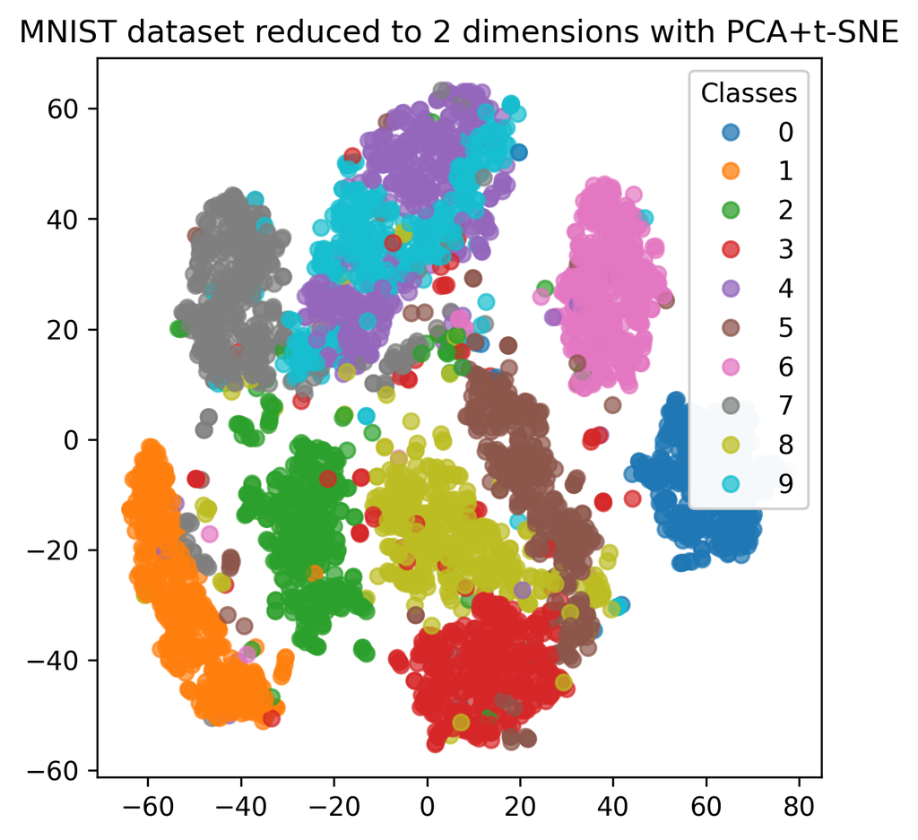

```python
pca = PCA(n_components=50)
mnist_data_train_pca = pca.fit_transform(mnist_data_train)
tsne = TSNE(n_components=2, perplexity=30, random_state=6886)
mnist_data_train_tsne = tsne.fit_transform(mnist_data_train_pca)
fig, ax = plt.subplots(figsize=(5, 5))
scatter = ax.scatter(mnist_data_train_tsne[:, 0], mnist_data_train_tsne[:, 1], c=mnist_labels_train, cmap='tab10', alpha=0.7)
legend = ax.legend(*scatter.legend_elements(), title='Classes')
ax.add_artist(legend)
ax.set_title('MNIST dataset reduced to 2 dimensions with PCA+t-SNE')
plt.show()
```

Вернёмся в статичный режим отрисовки изображений:

```python
%matplotlib inline
matplotlib.rcParams['figure.dpi'] = 300
```

#### **Задание 1.4 [код]**

Разбейте выборку следующим образом:

1. Разбейте случайным образом обучающую выборку на 2 части — размеченную и неразмеченную. Считайте, что доля размеченных объектов — `fraction_of_labeled`. Метки неразмеченной части замените на $-1$.
2. Тестовую выборку разбейте в соотношении $30$ на $70$ — меньшую часть (далее будет называться **валидационной выборкой**) используйте для подбора гиперпараметров, а большую (**тестовая выборка**) для итоговой оценки качества.

```python
fraction_of_labeled = 0.01
```

```python
X_train_labeled, X_train_unlabeled, y_train_labeled, y_train_unlabeled = train_test_split(mnist_data_train, mnist_labels_train, train_size=fraction_of_labeled, stratify=mnist_labels_train, random_state=42)
y_train_unlabeled[:] = -1
X_train = np.concatenate([X_train_labeled, X_train_unlabeled], axis=0)
y_train = np.concatenate([y_train_labeled, y_train_unlabeled], axis=0)
X_val, X_test, y_val, y_test = train_test_split(mnist_data_test, mnist_labels_test, test_size=0.7, random_state=42)
```

#### **Задание 1.5 [кросспроверка, 9 баллов][код]**

Используя MetaSemiSupervisedModel подберите оптимальные параметры:

- `C` — не менее $15$ точек в диапазоне $5-6$ десятичных порядков
- `n_clusters` — не менее $10$ точек вплоть до $100$
- `n_components` — не менее $7$ точек вплоть до $100$

для следующих моделей:

1. Исходные признаки + `LogisticRegression`
2. Исходные признаки + `SelfTrainingClassifier`
3. Исходные признаки + `KMeansClassifier`
4. `UMAP` + `LogisticRegression`
5. `UMAP` + `SelfTrainingClassifier`
6. `UMAP` + `KMeansClassifier`

Подбор каждого гиперпараметра должен быть сопровождён графиками точности на тестовой и валидационной выборках. Изобразите обе линии на одном графике.

При переборе **обязательно выводите значение найденного оптимального параметра и качество модели с оптимальным гиперпараметром** на выборке для итоговой оценки качества.

В последних трёх моделях используйте гиперпараметры базовых моделей, найденные в первых трёх моделях.

```python
from IPython.display import clear_output
```

```
LogisticRegression
```

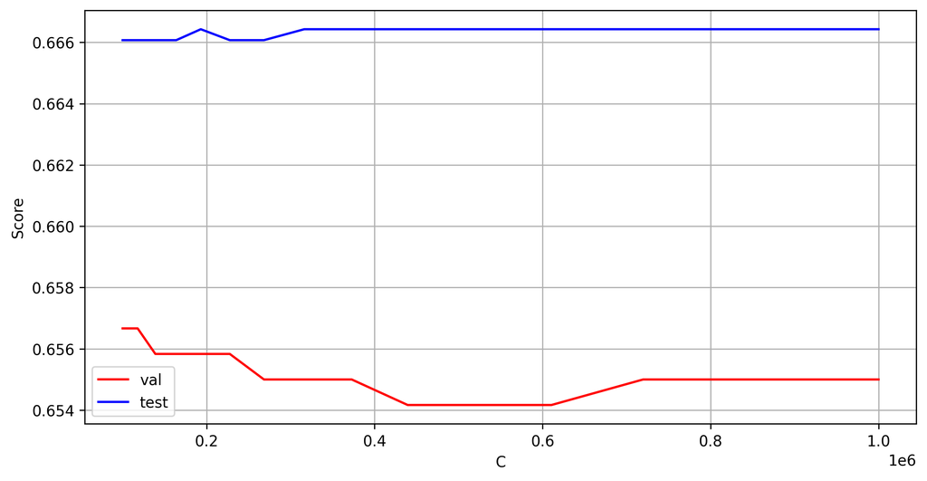

```python
model_k = {}
scores_val = []
scores_test = []
x = []

for c in np.logspace(5, 6, 15):
    model_k['C'] = c
    model = MetaSemiSupervisedModel(data_processing=None, model='LogisticRegression', reducer_kwargs=None, model_kwargs=model_k)
    model.fit(X_train, y_train)
    val_score = model.predict(X_val)
    test_score = model.predict(X_test)
    clear_output()
    a_val = sklearn.metrics.accuracy_score(val_score, y_val)
    a_test = sklearn.metrics.accuracy_score(test_score, y_test)
    scores_val.append(a_val)
    scores_test.append(a_test)
    x.append(c)

print('LogisticRegression')
plt.figure(figsize=(10,5))
plt.plot(x, scores_val, label = 'val', c = 'r')
plt.plot(x, scores_test, label = 'test', c = 'b')
plt.legend()
plt.ylabel('Score')
plt.xlabel('C')
plt.grid(True)
plt.show()
```

```python
model = MetaSemiSupervisedModel(data_processing=None, model='LogisticRegression', reducer_kwargs=None, model_kwargs={'C' : x[np.argmax(scores_test)]})
model.fit(X_train, y_train)
val_score = model.predict(X_val)
test_score = model.predict(X_test)
best_param1 = x[np.argmax(scores_test)]
print('Лучшее значение C:\t', x[np.argmax(scores_test)])
print('Точность на валидации:\t', sklearn.metrics.accuracy_score(val_score, y_val))
print('Точность на тестах:\t', sklearn.metrics.accuracy_score(test_score, y_test))
```

```
Лучшее значение C:	 193069.77288832495
Точность на валидации:	 0.6558333333333334
Точность на тестах:	 0.6664285714285715
```

```
SelfTrainingClassifier
```

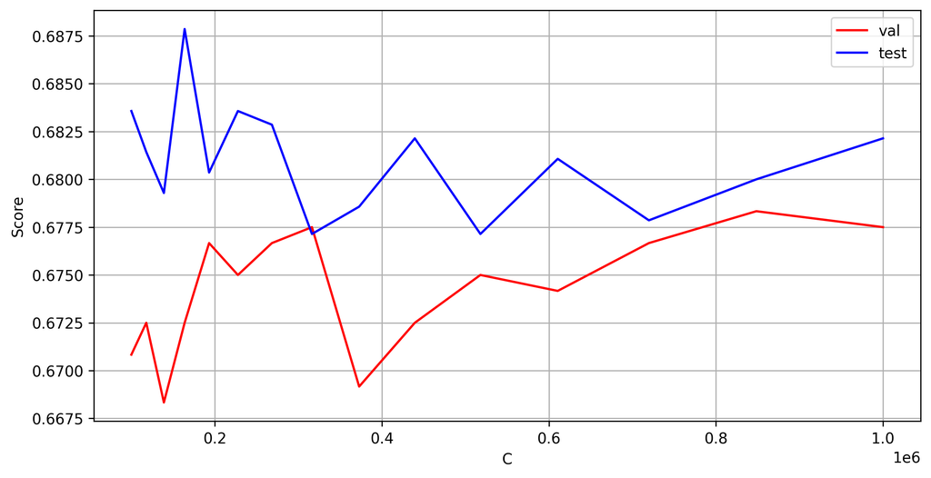

```python
model_k = {}
scores_val = []
scores_test = []
x = []

for c in np.logspace(5, 6, 15):
    model_k['C'] = c
    model = MetaSemiSupervisedModel(data_processing=None, model='SelfTrainingClassifier', reducer_kwargs=None, model_kwargs=model_k)
    model.fit(X_train, y_train)
    val_score = model.predict(X_val)
    test_score = model.predict(X_test)
    clear_output()
    a_val = sklearn.metrics.accuracy_score(val_score, y_val)
    a_test = sklearn.metrics.accuracy_score(test_score, y_test)
    scores_val.append(a_val)
    scores_test.append(a_test)
    x.append(c)

print('SelfTrainingClassifier')
plt.figure(figsize=(10,5))
plt.plot(x, scores_val, label = 'val', c = 'r')
plt.plot(x, scores_test, label = 'test', c = 'b')
plt.legend()
plt.ylabel('Score')
plt.xlabel('C')
plt.grid(True)
plt.show()
```

```python
model = MetaSemiSupervisedModel(data_processing=None, model='SelfTrainingClassifier', reducer_kwargs=None, model_kwargs={'C' : x[np.argmax(scores_test)]})
model.fit(X_train, y_train)
val_score = model.predict(X_val)
test_score = model.predict(X_test)
best_param1 = x[np.argmax(scores_test)]
print('Лучшее значение C:\t', x[np.argmax(scores_test)])
print('Точность на валидации:\t', sklearn.metrics.accuracy_score(val_score, y_val))
print('Точность на тестах:\t', sklearn.metrics.accuracy_score(test_score, y_test))
```

```
Лучшее значение C:	 163789.37069540645
Точность на валидации:	 0.6725
Точность на тестах:	 0.6878571428571428
```

```
KMeansClassifier
```

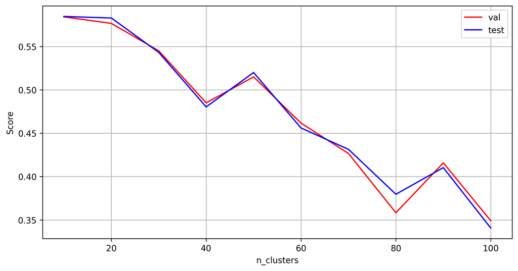

```python
model_k = {}
scores_val = []
scores_test = []
x = []

for n_clusters in range(10, 101, 10):
    model_k['n_clusters'] = n_clusters
    model = MetaSemiSupervisedModel(data_processing=None, model='KMeansClassifier', reducer_kwargs=None, model_kwargs=model_k)
    model.fit(X_train, y_train)
    val_score = model.predict(X_val)
    test_score = model.predict(X_test)
    clear_output()
    a_val = sklearn.metrics.accuracy_score(val_score, y_val)
    a_test = sklearn.metrics.accuracy_score(test_score, y_test)
    scores_val.append(a_val)
    scores_test.append(a_test)
    x.append(n_clusters)

print('KMeansClassifier')
plt.figure(figsize=(10,5))
plt.plot(x, scores_val, label = 'val', c = 'r')
plt.plot(x, scores_test, label = 'test', c = 'b')
plt.legend()
plt.ylabel('Score')
plt.xlabel('n_clusters')
plt.grid(True)
plt.show()
```

```python
model = MetaSemiSupervisedModel(data_processing=None, model='KMeansClassifier', reducer_kwargs=None, model_kwargs={'n_clusters' : x[np.argmax(scores_test)]})
model.fit(X_train, y_train)
val_score = model.predict(X_val)
test_score = model.predict(X_test)
best_param1 = x[np.argmax(scores_test)]
print('Лучшее значение n_clusters:\t', x[np.argmax(scores_test)])
print('Точность на валидации:\t\t', sklearn.metrics.accuracy_score(val_score, y_val))
print('Точность на тестах:\t\t', sklearn.metrics.accuracy_score(test_score, y_test))
```

```
Лучшее значение n_clusters:	 10
Точность на валидации:		 0.5891666666666666
Точность на тестах:		 0.5846428571428571
```

```
UMAP & LogisticRegression
```

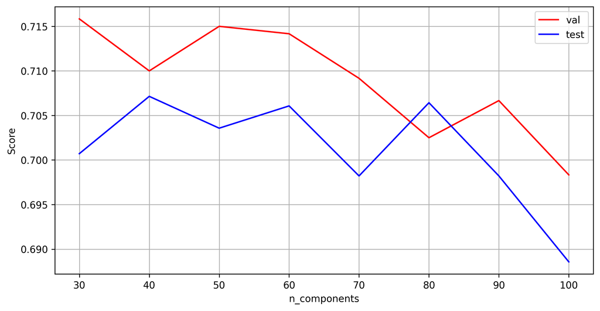

```python
reducer_k = {}
scores_val = []
scores_test = []
x = []

for n_components in range(30, 101, 10):
  reducer_k['n_components'] = n_components
  model = MetaSemiSupervisedModel(data_processing='UMAP', model='LogisticRegression', reducer_kwargs=reducer_k, model_kwargs={'C' : best_param1})
  model.fit(X_train, y_train)
  val_score = model.predict(X_val)
  test_score = model.predict(X_test)
  clear_output()
  a_val = sklearn.metrics.accuracy_score(val_score, y_val)
  a_test = sklearn.metrics.accuracy_score(test_score, y_test)
  scores_val.append(a_val)
  scores_test.append(a_test)
  x.append(n_components)

print('UMAP & LogisticRegression')
plt.figure(figsize=(10,5))
plt.plot(x, scores_val, label = 'val', c = 'r')
plt.plot(x, scores_test, label = 'test', c = 'b')
plt.legend()
plt.ylabel('Score')
plt.xlabel('n_components')
plt.grid(True)
plt.show()
```

```python
model = MetaSemiSupervisedModel(data_processing='UMAP', model='LogisticRegression', reducer_kwargs={'n_components' : x[np.argmax(scores_test)]}, model_kwargs={'C' : best_param1})
model.fit(X_train, y_train)
val_score = model.predict(X_val)
test_score = model.predict(X_test)
best_param1 = x[np.argmax(scores_test)]
print('Лучшее значение n_components:\t', x[np.argmax(scores_test)])
print('Точность на валидации:\t\t', sklearn.metrics.accuracy_score(val_score, y_val))
print('Точность на тестах:\t\t', sklearn.metrics.accuracy_score(test_score, y_test))
```

```
Лучшее значение n_components:	 40
Точность на валидации:		 0.7183333333333334
Точность на тестах:		 0.7092857142857143
```

```
UMAP & SelfTrainingClassifier
```

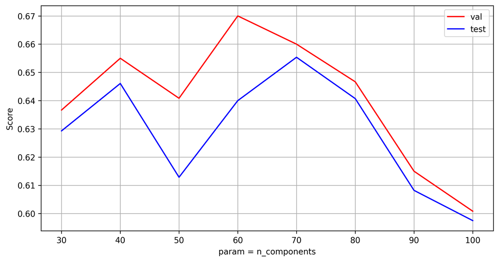

```python
reducer_k = {}
scores_val = []
scores_test = []
x = []

for n_components in range(30, 101, 10):
    reducer_k['n_components'] = n_components
    model = MetaSemiSupervisedModel(data_processing='UMAP', model='SelfTrainingClassifier', reducer_kwargs=reducer_k, model_kwargs={'C' : 163789.37069540645})
    model.fit(X_train, y_train)
    val_score = model.predict(X_val)
    test_score = model.predict(X_test)
    clear_output()
    a_val = sklearn.metrics.accuracy_score(val_score, y_val)
    a_test = sklearn.metrics.accuracy_score(test_score, y_test)
    scores_val.append(a_val)
    scores_test.append(a_test)
    x.append(n_components)

print('UMAP & SelfTrainingClassifier')
plt.figure(figsize=(10,5))
plt.plot(x, scores_val, label = 'val', c = 'r')
plt.plot(x, scores_test, label = 'test', c = 'b')
plt.legend()
plt.ylabel('Score')
plt.xlabel('param = n_components')
plt.grid(True)
plt.show()
```

```python
model = MetaSemiSupervisedModel(data_processing='UMAP', model='SelfTrainingClassifier', reducer_kwargs={'n_components' : x[np.argmax(scores_test)]}, model_kwargs={'C' : 163789.37069540645})
model.fit(X_train, y_train)
val_score = model.predict(X_val)
test_score = model.predict(X_test)
best_param1 = x[np.argmax(scores_test)]
print('Лучшее значение n_components:\t', x[np.argmax(scores_test)])
print('Точность на валидации:\t\t', sklearn.metrics.accuracy_score(val_score, y_val))
print('Точность на тестах:\t\t', sklearn.metrics.accuracy_score(test_score, y_test))
```

```
Лучшее значение n_components:	 70
Точность на валидации:		 0.6466666666666666
Точность на тестах:		 0.6442857142857142
```

```
UMAP & KMeansClassifier
```

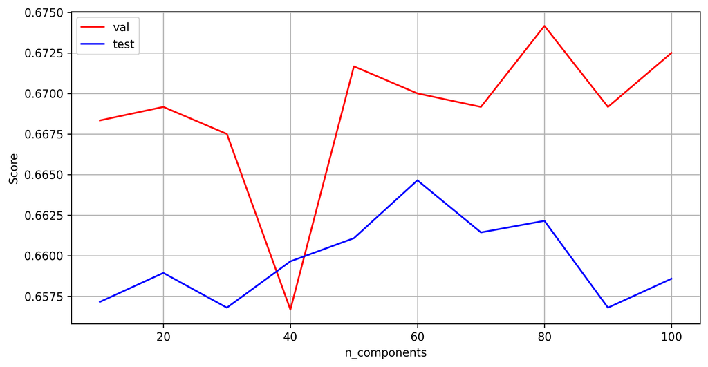

```python
reducer_k = {}
scores_val = []
scores_test = []
x = []

for n_components in range(10, 101, 10):
    reducer_k['n_components'] = n_components
    model = MetaSemiSupervisedModel(data_processing='UMAP', model='KMeansClassifier', reducer_kwargs=reducer_k, model_kwargs={'n_clusters' : 10})
    model.fit(X_train, y_train)
    val_score = model.predict(X_val)
    test_score = model.predict(X_test)
    clear_output()
    a_val = sklearn.metrics.accuracy_score(val_score, y_val)
    a_test = sklearn.metrics.accuracy_score(test_score, y_test)
    scores_val.append(a_val)
    scores_test.append(a_test)
    x.append(n_components)

print('UMAP & KMeansClassifier')
plt.figure(figsize=(10,5))
plt.plot(x, scores_val, label = 'val', c = 'r')
plt.plot(x, scores_test, label = 'test', c = 'b')
plt.legend()
plt.ylabel('Score')
plt.xlabel('n_components')
plt.grid(True)
plt.show()
```

```python
model = MetaSemiSupervisedModel(data_processing='UMAP', model='KMeansClassifier', reducer_kwargs={'n_components' : x[np.argmax(scores_test)]}, model_kwargs={'n_clusters' : 10})
model.fit(X_train, y_train)
val_score = model.predict(X_val)
test_score = model.predict(X_test)
best_param1 = x[np.argmax(scores_test)]
print('Лучшее значение n_components:\t', x[np.argmax(scores_test)])
print('Точность на валидации:\t\t', sklearn.metrics.accuracy_score(val_score, y_val))
print('Точность на тестах:\t\t', sklearn.metrics.accuracy_score(test_score, y_test))
```

```
Лучшее значение n_components:	 60
Точность на валидации:		 0.6675
Точность на тестах:		 0.6610714285714285
```

#### **Задание 1.6 [кросспроверка, 9 баллов][вопрос]**

Опишите полученные результаты. Какая модель проявила себя лучше всего? Как влияет на результат снижение размерности признакового пространства?

#### **Задание 1.7 [кросспроверка, 6 баллов][код]**

Обучите каждую из шести моделей на выборках с разной долей размеченных объектов. Используйте оптимальные параметры из предыдущего пункта. Изобразите итоговое качество в зависимости от доли размеченных объектов для всех моделей на одном графике.

Используйте сетку для перебора, указанную ниже. При желании можете взять больше точек.

```python
fraction_of_labeled_range = [0.005, 0.01, 0.05, 0.1, 0.2, 0.5, 0.7, 0.99]
```

```python
N_KMeans = []
UMAP_KMeans = []
N_LogisticRegression = []
UMAP_LogisticRegression = []
N_SelfTrainingClassifier = []
UMAP_SelfTrainingClassifier = []

for fraction_of_labeled in fraction_of_labeled_range:
    X_train_labeled, X_train_unlabeled, y_train_labeled, y_train_unlabeled = train_test_split(mnist_data_train, mnist_labels_train, train_size=fraction_of_labeled, stratify=mnist_labels_train, random_state=42)
    y_train_unlabeled[:] = -1
    X_train = np.concatenate([X_train_labeled, X_train_unlabeled], axis=0)
    y_train = np.concatenate([y_train_labeled, y_train_unlabeled], axis=0)
    X_val, X_test, y_val, y_test = train_test_split(mnist_data_test, mnist_labels_test, test_size=0.7, random_state=42)
    model = MetaSemiSupervisedModel(data_processing='UMAP', model='KMeansClassifier', reducer_kwargs={'n_components' : 100}, model_kwargs={'n_clusters' : 10})
    model.fit(X_train, y_train)
    test_score = model.predict(X_test)
    UMAP_KMeans.append(sklearn.metrics.accuracy_score(test_score, y_test))

for fraction_of_labeled in fraction_of_labeled_range:
    X_train_labeled, X_train_unlabeled, y_train_labeled, y_train_unlabeled = train_test_split(mnist_data_train, mnist_labels_train, train_size=fraction_of_labeled, stratify=mnist_labels_train, random_state=42)
    y_train_unlabeled[:] = -1
    X_train = np.concatenate([X_train_labeled, X_train_unlabeled], axis=0)
    y_train = np.concatenate([y_train_labeled, y_train_unlabeled], axis=0)
    X_val, X_test, y_val, y_test = train_test_split(mnist_data_test, mnist_labels_test, test_size=0.7, random_state=42)
    model = MetaSemiSupervisedModel(data_processing='UMAP', model='SelfTrainingClassifier', reducer_kwargs={'n_components' : 30}, model_kwargs={'C' : 163789.37069540645})
    model.fit(X_train, y_train)
    test_score = model.predict(X_test)
    UMAP_SelfTrainingClassifier.append(sklearn.metrics.accuracy_score(test_score, y_test))

for fraction_of_labeled in fraction_of_labeled_range:
    X_train_labeled, X_train_unlabeled, y_train_labeled, y_train_unlabeled = train_test_split(mnist_data_train, mnist_labels_train, train_size=fraction_of_labeled, stratify=mnist_labels_train, random_state=42)
    y_train_unlabeled[:] = -1
    X_train = np.concatenate([X_train_labeled, X_train_unlabeled], axis=0)
    y_train = np.concatenate([y_train_labeled, y_train_unlabeled], axis=0)
    X_val, X_test, y_val, y_test = train_test_split(mnist_data_test, mnist_labels_test, test_size=0.7, random_state=42)
    model = MetaSemiSupervisedModel(data_processing='UMAP', model='LogisticRegression', reducer_kwargs={'n_components' : 40}, model_kwargs={'C' : 193069.77288832495})
    model.fit(X_train, y_train)
    test_score = model.predict(X_test)
    UMAP_LogisticRegression.append(sklearn.metrics.accuracy_score(test_score, y_test))

for fraction_of_labeled in fraction_of_labeled_range:
    X_train_labeled, X_train_unlabeled, y_train_labeled, y_train_unlabeled = train_test_split(mnist_data_train, mnist_labels_train, train_size=fraction_of_labeled, stratify=mnist_labels_train, random_state=42)
    y_train_unlabeled[:] = -1
    X_train = np.concatenate([X_train_labeled, X_train_unlabeled], axis=0)
    y_train = np.concatenate([y_train_labeled, y_train_unlabeled], axis=0)
    X_val, X_test, y_val, y_test = train_test_split(mnist_data_test, mnist_labels_test, test_size=0.7, random_state=42)
    model = MetaSemiSupervisedModel(data_processing=None, model='KMeansClassifier', reducer_kwargs={'n_components' : 100}, model_kwargs={'n_clusters' : 10})
    model.fit(X_train, y_train)
    test_score = model.predict(X_test)
    N_KMeans.append(sklearn.metrics.accuracy_score(test_score, y_test))

for fraction_of_labeled in fraction_of_labeled_range:
    X_train_labeled, X_train_unlabeled, y_train_labeled, y_train_unlabeled = train_test_split(mnist_data_train, mnist_labels_train, train_size=fraction_of_labeled, stratify=mnist_labels_train, random_state=42)
    y_train_unlabeled[:] = -1
    X_train = np.concatenate([X_train_labeled, X_train_unlabeled], axis=0)
    y_train = np.concatenate([y_train_labeled, y_train_unlabeled], axis=0)
    X_val, X_test, y_val, y_test = train_test_split(mnist_data_test, mnist_labels_test, test_size=0.7, random_state=42)
    model = MetaSemiSupervisedModel(data_processing=None, model='SelfTrainingClassifier', reducer_kwargs={'n_components' : 30}, model_kwargs={'C' : 163789.37069540645})
    model.fit(X_train, y_train)
    test_score = model.predict(X_test)
    N_SelfTrainingClassifier.append(sklearn.metrics.accuracy_score(test_score, y_test))

for fraction_of_labeled in fraction_of_labeled_range:
    X_train_labeled, X_train_unlabeled, y_train_labeled, y_train_unlabeled = train_test_split(mnist_data_train, mnist_labels_train, train_size=fraction_of_labeled, stratify=mnist_labels_train, random_state=42)
    y_train_unlabeled[:] = -1
    X_train = np.concatenate([X_train_labeled, X_train_unlabeled], axis=0)
    y_train = np.concatenate([y_train_labeled, y_train_unlabeled], axis=0)
    X_val, X_test, y_val, y_test = train_test_split(mnist_data_test, mnist_labels_test, test_size=0.7, random_state=42)
    model = MetaSemiSupervisedModel(data_processing=None, model='LogisticRegression', reducer_kwargs={'n_components' : 40}, model_kwargs={'C' : 193069.77288832495})
    model.fit(X_train, y_train)
    test_score = model.predict(X_test)
    N_LogisticRegression.append(sklearn.metrics.accuracy_score(test_score, y_test))
```

[output not shown]

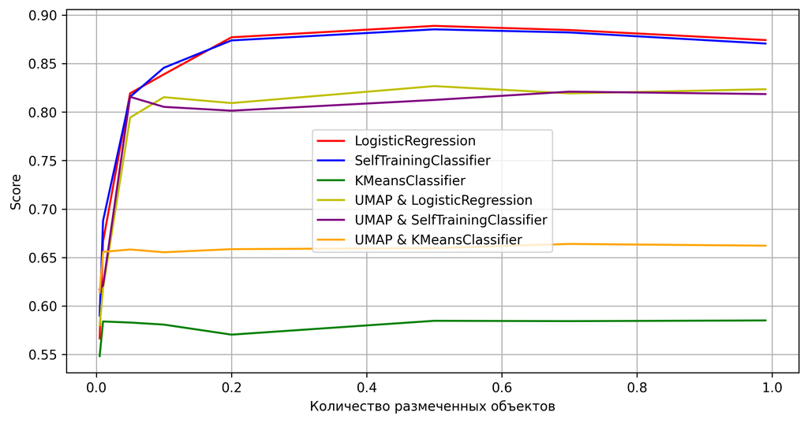

```python
plt.figure(figsize=(10, 5))
plt.plot(fraction_of_labeled_range, N_LogisticRegression, label = 'LogisticRegression', c = 'r')
plt.plot(fraction_of_labeled_range, N_SelfTrainingClassifier, label = 'SelfTrainingClassifier', c = 'b')
plt.plot(fraction_of_labeled_range, N_KMeans, label = 'KMeansClassifier', c = 'g')
plt.plot(fraction_of_labeled_range, UMAP_LogisticRegression, label = 'UMAP & LogisticRegression', c = 'y')
plt.plot(fraction_of_labeled_range, UMAP_SelfTrainingClassifier, label = 'UMAP & SelfTrainingClassifier', c = 'purple')
plt.plot(fraction_of_labeled_range, UMAP_KMeans, label = 'UMAP & KMeansClassifier', c = 'orange')
plt.legend()
plt.ylabel('Score')
plt.xlabel('Количество размеченных объектов')
plt.grid(True)
plt.show()
```

```python
print(N_LogisticRegression)
print(N_SelfTrainingClassifier)
print(N_KMeans)
print(UMAP_LogisticRegression)
print(UMAP_SelfTrainingClassifier)
print(UMAP_KMeans)
```

```
[0.5664285714285714, 0.6664285714285715, 0.8192857142857143, 0.8389285714285715, 0.8771428571428571, 0.8889285714285714, 0.8846428571428572, 0.8742857142857143]
[0.59, 0.6878571428571428, 0.8157142857142857, 0.8457142857142858, 0.8739285714285714, 0.8853571428571428, 0.8821428571428571, 0.8707142857142857]
[0.5482142857142858, 0.5839285714285715, 0.5828571428571429, 0.5807142857142857, 0.5703571428571429, 0.5846428571428571, 0.5842857142857143, 0.585]
[0.58, 0.6182142857142857, 0.7942857142857143, 0.8153571428571429, 0.8092857142857143, 0.8267857142857142, 0.8192857142857143, 0.8235714285714286]
[0.6171428571428571, 0.6210714285714286, 0.8157142857142857, 0.8053571428571429, 0.8014285714285714, 0.8125, 0.8210714285714286, 0.8185714285714286]
[0.6135714285714285, 0.6557142857142857, 0.6582142857142858, 0.6553571428571429, 0.6585714285714286, 0.6596428571428572, 0.6639285714285714, 0.6621428571428571]
```

#### **Задание 1.8 [кросспроверка, 6 баллов][вопрос]**

Как разные модели ведут себя в зависимости от объёма размеченных данных? Какой размер выборки достаточно разметить, чтобы получить близкое к максимальному качество? В каких случаях может быть выгодно использовать методы снижения размерности?

*Ваш ответ здесь:*

**1. Увелечение доли размеченных объектов -> улучшение точности моделей**

**2. На модели KMeansClassifier не влияет параметр**

**3. Достаточно взять значение 0.2 для получения наиболее близких к максимальным качествам значения**

#### **Задание 1.9 [бонус, 3 балла]**

Вставьте картинку/музыку/текст и пр., описывающее ваше ощущение от погружения в ML :)

[figure not shown]